# 승리에 가장 큰 영향을 주는 스텟은 무엇인가?

## 준비

- 패키지 설치
- 라이브러리 부착
- 데이터 불러오기 - json

### 패키지 설치

```r
# install.packages('jsonlite')
# install.packages('ggplot2')
# install.packages('ggthemes')
```

### 라이브러리

```r
library(jsonlite)
library('ggplot2')
library('ggthemes')
```

### 데이터 가져오기

```r
# 최근 다섯 시즌 모든 팀의 경기 데이터를 불러오기
data = fromJSON('/programming/project/AllTeam.json')
```

### 데이터 프레임 생성

- 데이터 프레임 생성
- 변수명 변경
- 불필요한 변수 제거

```r
# 데이터 프레임 생성
data = data.frame(data)
head(data, 3)
```

| list.Team | list.Matchyear | list.Matchday | list.WinorLose | list.Formation | list.Possession | list.Shots | list.Shots_on_Target | list.Touches | list.Passes | list.Tackles | list.Clearances | list.Corners | list.Offsides | list.Yellow_cards | list.Red_cards | list.Fouls_conceded | list.num |
| --- | --- | --- | --- | --- | --- | --- | --- | --- | --- | --- | --- | --- | --- | --- | --- | --- | --- |
| AFC Bournemouth | 2015/16 | Sat 8 Aug 2015, 15:00 BST | 0 | 442 | 58.4 | 11 | 2 | 747 | 548 | 14 | 16 | 6 | 0 | 3 | 0 | 13 | 8986 |
| Aston Villa | 2015/16 | Sat 8 Aug 2015, 15:00 BST | 1 | 433 | 41.6 | 7 | 3 | 604 | 391 | 24 | 39 | 3 | 0 | 4 | 0 | 13 | 8986 |
| Chelsea | 2015/16 | Sat 8 Aug 2015, 17:30 BST | 2 | 4231 | 52.0 | 11 | 3 | 635 | 433 | 16 | 14 | 4 | 2 | 1 | 1 | 15 | 8987 |

```r
# 새로운 변수명 생성
new_list  <-c('Team','Matchyear','Matchday','WinorLose','Formation','Possession','Shots','Shots_on_target','Touches','Passes','Tackles','Clearances','Corners','Offsides','Yellow_cards','Red_cards','Foul_conceded','num')
```

```r
# 변수명 확인
colnames(data)  <- new_list
colnames(data)
```

1. 'Team'

2. 'Matchyear'

3. 'Matchday'

4. 'WinorLose'

5. 'Formation'

6. 'Possession'

7. 'Shots'

8. 'Shots_on_target'

9. 'Touches'

10. 'Passes'

11. 'Tackles'

12. 'Clearances'

13. 'Corners'

14. 'Offsides'

15. 'Yellow_cards'

16. 'Red_cards'

17. 'Foul_conceded'

18. 'num'

```r
# 불필요한 변수 제거
# 팀명, 경기년도, 경기일, 포메이션, 경기식별번호
data2  <-  subset(data, select = c(-Team,-Matchyear,-Matchday, -num, -Formation))
```

```r
# 불필요 변수 제거 확인
head(data2, 3)
```

| WinorLose | Possession | Shots | Shots_on_target | Touches | Passes | Tackles | Clearances | Corners | Offsides | Yellow_cards | Red_cards | Foul_conceded |
| --- | --- | --- | --- | --- | --- | --- | --- | --- | --- | --- | --- | --- |
| 0 | 58.4 | 11 | 2 | 747 | 548 | 14 | 16 | 6 | 0 | 3 | 0 | 13 |
| 1 | 41.6 | 7 | 3 | 604 | 391 | 24 | 39 | 3 | 0 | 4 | 0 | 13 |
| 2 | 52.0 | 11 | 3 | 635 | 433 | 16 | 14 | 4 | 2 | 1 | 1 | 15 |

### 승패와 각 변수에 따른 테이블 만들기

```r
# 점유율 수치에 따른 경기 결과(패, 승, 무) 빈도를 테이블로 생성
# 칼럼 : 점유율 수치를 표기, 간격은 2로 설정(간격이 너무 좁을 경우 데이터가 퍼져 분석이 어렵기 때문에 적절한 간격을 설정)
# 0 : 패배 수, 1 : 승리 수, 2 : 무승부 수
Possession1  <- table(data2$WinorLose, round(data2$Possession/2)*2)
Possession1
```

```
    18 20 22 24 26 28 30 32 34 36 38 40 42 44 46 48 50 52 54 56 58 60 62 64 66
  0  4  5 13 21 30 33 46 58 53 69 70 71 77 78 78 90 66 87 81 79 60 64 45 39 35
  1  0  2  4  6  9 19 26 29 35 39 45 64 60 79 81 87 66 90 78 78 77 71 70 69 53
  2  1  2  1  4  7 21 16 23 28 32 37 46 49 57 54 49 52 49 54 57 49 46 37 32 28

    68 70 72 74 76 78 80 82
  0 29 26 19  9  6  4  2  0
  1 58 46 33 30 21 13  5  4
  2 23 16 21  7  4  1  2  1
```

```r
# 긱 점유율 수치에서  패, 승, 무 빈도 수치를 백분율로 표시
Possession2  <- prop.table(Possession1, margin =2)
Possession2
```

```
            18         20         22         24         26         28
  0 0.80000000 0.55555556 0.72222222 0.67741935 0.65217391 0.45205479
  1 0.00000000 0.22222222 0.22222222 0.19354839 0.19565217 0.26027397
  2 0.20000000 0.22222222 0.05555556 0.12903226 0.15217391 0.28767123

            30         32         34         36         38         40
  0 0.52272727 0.52727273 0.45689655 0.49285714 0.46052632 0.39226519
  1 0.29545455 0.26363636 0.30172414 0.27857143 0.29605263 0.35359116
  2 0.18181818 0.20909091 0.24137931 0.22857143 0.24342105 0.25414365

            42         44         46         48         50         52
  0 0.41397849 0.36448598 0.36619718 0.39823009 0.35869565 0.38495575
  1 0.32258065 0.36915888 0.38028169 0.38495575 0.35869565 0.39823009
  2 0.26344086 0.26635514 0.25352113 0.21681416 0.28260870 0.21681416

            54         56         58         60         62         64
  0 0.38028169 0.36915888 0.32258065 0.35359116 0.29605263 0.27857143
  1 0.36619718 0.36448598 0.41397849 0.39226519 0.46052632 0.49285714
  2 0.25352113 0.26635514 0.26344086 0.25414365 0.24342105 0.22857143

            66         68         70         72         74         76
  0 0.30172414 0.26363636 0.29545455 0.26027397 0.19565217 0.19354839
  1 0.45689655 0.52727273 0.52272727 0.45205479 0.65217391 0.67741935
  2 0.24137931 0.20909091 0.18181818 0.28767123 0.15217391 0.12903226

            78         80         82
  0 0.22222222 0.22222222 0.00000000
  1 0.72222222 0.55555556 0.80000000
  2 0.05555556 0.22222222 0.20000000
```

```r
# 점유율 수치에 따른 전체 경기 수와 승리 비율을 데이터프레임으로 생성
Possession  <- data.frame(colnames(Possession2), Possession1[1,]+Possession1[2,]+Possession1[3,], Possession2[2,] )
Possession
```

|  | colnames.Possession2. | Possession1.1......Possession1.2......Possession1.3... | Possession2.2... |
| --- | --- | --- | --- |
| 18 | 18 | 5 | 0.0000000 |
| 20 | 20 | 9 | 0.2222222 |
| 22 | 22 | 18 | 0.2222222 |
| 24 | 24 | 31 | 0.1935484 |
| 26 | 26 | 46 | 0.1956522 |
| 28 | 28 | 73 | 0.2602740 |
| 30 | 30 | 88 | 0.2954545 |
| 32 | 32 | 110 | 0.2636364 |
| 34 | 34 | 116 | 0.3017241 |
| 36 | 36 | 140 | 0.2785714 |
| 38 | 38 | 152 | 0.2960526 |
| 40 | 40 | 181 | 0.3535912 |
| 42 | 42 | 186 | 0.3225806 |
| 44 | 44 | 214 | 0.3691589 |
| 46 | 46 | 213 | 0.3802817 |
| 48 | 48 | 226 | 0.3849558 |
| 50 | 50 | 184 | 0.3586957 |
| 52 | 52 | 226 | 0.3982301 |
| 54 | 54 | 213 | 0.3661972 |
| 56 | 56 | 214 | 0.3644860 |
| 58 | 58 | 186 | 0.4139785 |
| 60 | 60 | 181 | 0.3922652 |
| 62 | 62 | 152 | 0.4605263 |
| 64 | 64 | 140 | 0.4928571 |
| 66 | 66 | 116 | 0.4568966 |
| 68 | 68 | 110 | 0.5272727 |
| 70 | 70 | 88 | 0.5227273 |
| 72 | 72 | 73 | 0.4520548 |
| 74 | 74 | 46 | 0.6521739 |
| 76 | 76 | 31 | 0.6774194 |
| 78 | 78 | 18 | 0.7222222 |
| 80 | 80 | 9 | 0.5555556 |
| 82 | 82 | 5 | 0.8000000 |

```r
# 불필요한 row 제거
rownames(Possession)  <-  NULL
# 변수명 수정
colnames(Possession)  <- c('Possession', 'number','winrate')
# 점유율(Possession)의 문자형 값을 정수화
Possession$Possession  <- as.numeric(as.character(Possession$Possession))

# 확인
Possession
```

| Possession | number | winrate |
| --- | --- | --- |
| 18 | 5 | 0.0000000 |
| 20 | 9 | 0.2222222 |
| 22 | 18 | 0.2222222 |
| 24 | 31 | 0.1935484 |
| 26 | 46 | 0.1956522 |
| 28 | 73 | 0.2602740 |
| 30 | 88 | 0.2954545 |
| 32 | 110 | 0.2636364 |
| 34 | 116 | 0.3017241 |
| 36 | 140 | 0.2785714 |
| 38 | 152 | 0.2960526 |
| 40 | 181 | 0.3535912 |
| 42 | 186 | 0.3225806 |
| 44 | 214 | 0.3691589 |
| 46 | 213 | 0.3802817 |
| 48 | 226 | 0.3849558 |
| 50 | 184 | 0.3586957 |
| 52 | 226 | 0.3982301 |
| 54 | 213 | 0.3661972 |
| 56 | 214 | 0.3644860 |
| 58 | 186 | 0.4139785 |
| 60 | 181 | 0.3922652 |
| 62 | 152 | 0.4605263 |
| 64 | 140 | 0.4928571 |
| 66 | 116 | 0.4568966 |
| 68 | 110 | 0.5272727 |
| 70 | 88 | 0.5227273 |
| 72 | 73 | 0.4520548 |
| 74 | 46 | 0.6521739 |
| 76 | 31 | 0.6774194 |
| 78 | 18 | 0.7222222 |
| 80 | 9 | 0.5555556 |
| 82 | 5 | 0.8000000 |

## 위 과정을 다른 스텟에도 동일하게 적용

- 각 스텟별 간격 설정은 다음과 같다. (간격이 너무 좁을 경우 데이터가 퍼져 분석이 어렵기 때문에 적절한 간격을 설정)
- 슛:2, 유효슛:1, 터치:50, 패스:50, 태클:1, 클리어링:2, 코너킥:1, 오프사이드:1, 옐로카드:1, 레드카드:1, 파울:1

```r
# 승률과 슛 테이블
Shots1  <- table(data2$WinorLose, round(data2$Shots/2)*2)
Shots2  <- prop.table(Shots1, margin =2)
Shots  <- data.frame(colnames(Shots2), Shots1[1,]+Shots1[2,]+Shots1[3,], Shots2[2,] )
rownames(Shots)  <-  NULL
colnames(Shots)  <- c('Shots', 'number','winrate')
Shots$Shots  <- as.numeric(as.character(Shots$Shots))

# 승률과 유효슛 테이블
Shots_on_target1  <- table(data2$WinorLose, data2$Shots_on_target)
Shots_on_target2  <- prop.table(Shots_on_target1, margin =2)
Shots_on_target  <- data.frame(colnames(Shots_on_target2), Shots_on_target1[1,]+Shots_on_target1[2,]+Shots_on_target1[3,], Shots_on_target2[2,] )
rownames(Shots_on_target)  <-  NULL
colnames(Shots_on_target)  <- c('Shots_on_target', 'number','winrate')
Shots_on_target$Shots_on_target  <- as.numeric(as.character(Shots_on_target$Shots_on_target))

# 승률과 터치 테이블
Touches1  <- table(data2$WinorLose, round(data2$Touches/50)*50)
Touches2  <- prop.table(Touches1, margin =2)
Touches  <- data.frame(colnames(Touches2), Touches1[1,]+Touches1[2,]+Touches1[3,], Touches2[2,] )
rownames(Touches)  <-  NULL
colnames(Touches)  <- c('Touches', 'number','winrate')
Touches$Touches  <- as.numeric(as.character(Touches$Touches))

# 승률과 패스 테이블
Passes1  <- table(data2$WinorLose, round(data2$Passes/50)*50)
Passes2  <- prop.table(Passes1, margin =2)
Passes  <- data.frame(colnames(Passes2), Passes1[1,]+Passes1[2,]+Passes1[3,], Passes2[2,] )
rownames(Passes)  <-  NULL
colnames(Passes)  <- c('Passes', 'number','winrate')
Passes$Passes  <- as.numeric(as.character(Passes$Passes))

# 승률과 태클 테이블
Tackles1  <- table(data2$WinorLose, data2$Tackles)
Tackles2  <- prop.table(Tackles1, margin =2)
Tackles  <- data.frame(colnames(Tackles2), Tackles1[1,]+Tackles1[2,]+Tackles1[3,], Tackles2[2,] )
rownames(Tackles)  <-  NULL
colnames(Tackles)  <- c('Tackles', 'number','winrate')
Tackles$Tackles  <- as.numeric(as.character(Tackles$Tackles))

# 승률과 클리어링 테이블
Clearances1  <- table(data2$WinorLose, round(data2$Clearances/2)*2)
Clearances2  <- prop.table(Clearances1, margin =2)
Clearances  <- data.frame(colnames(Clearances2), Clearances1[1,]+Clearances1[2,]+Clearances1[3,], Clearances2[2,] )
rownames(Clearances)  <-  NULL
colnames(Clearances)  <- c('Clearances', 'number','winrate')
Clearances$Clearances  <- as.numeric(as.character(Clearances$Clearances))

# 승률과 코너킥 테이블
Corners1  <- table(data2$WinorLose, data2$Corners)
Corners2  <- prop.table(Corners1, margin =2)
Corners  <- data.frame(colnames(Corners2), Corners1[1,]+Corners1[2,]+Corners1[3,], Corners2[2,] )
rownames(Corners)  <-  NULL
colnames(Corners)  <- c('Corners', 'number','winrate')
Corners$Corners  <- as.numeric(as.character(Corners$Corners))

# 승률과 오프사이드 테이블
Offsides1  <- table(data2$WinorLose, round(data2$Offsides))
Offsides2  <- prop.table(Offsides1, margin =2)
Offsides  <- data.frame(colnames(Offsides2), Offsides1[1,]+Offsides1[2,]+Offsides1[3,], Offsides2[2,] )
rownames(Offsides)  <-  NULL
colnames(Offsides)  <- c('Offsides', 'number','winrate')
Offsides$Offsides  <- as.numeric(as.character(Offsides$Offsides))

# 승률과 옐로카드 테이블
Yellow_cards1  <- table(data2$WinorLose, round(data2$Yellow_cards))
Yellow_cards2  <- prop.table(Yellow_cards1, margin =2)
Yellow_cards  <- data.frame(colnames(Yellow_cards2), Yellow_cards1[1,]+Yellow_cards1[2,]+Yellow_cards1[3,], Yellow_cards2[2,] )
rownames(Yellow_cards)  <-  NULL
colnames(Yellow_cards)  <- c('Yellow_cards', 'number','winrate')
Yellow_cards$Yellow_cards  <- as.numeric(as.character(Yellow_cards$Yellow_cards))

# 승률과 레드카드 테이블
Red_cards1  <- table(data2$WinorLose, round(data2$Red_cards))
Red_cards2  <- prop.table(Red_cards1, margin =2)
Red_cards  <- data.frame(colnames(Red_cards2), Red_cards1[1,]+Red_cards1[2,]+Red_cards1[3,], Red_cards2[2,] )
rownames(Red_cards)  <-  NULL
colnames(Red_cards)  <- c('Red_cards', 'number','winrate')
Red_cards$Red_cards  <- as.numeric(as.character(Red_cards$Red_cards))

# 승률과 파울 테이블
Foul_conceded1  <- table(data2$WinorLose, round(data2$Foul_conceded))
Foul_conceded2  <- prop.table(Foul_conceded1, margin =2)
Foul_conceded  <- data.frame(colnames(Foul_conceded2), Foul_conceded1[1,]+Foul_conceded1[2,]+Foul_conceded1[3,], Foul_conceded2[2,] )
rownames(Foul_conceded)  <-  NULL
colnames(Foul_conceded)  <- c('Foul_conceded', 'number','winrate')
Foul_conceded$Foul_conceded  <- as.numeric(as.character(Foul_conceded$Foul_conceded))
```

# 분석과정

- 1. 변수의 수치와 승률의 상관관계
- 1. 분석 결과를 산점도 시각화

```r
Corners
```

| Corners | number | winrate |
| --- | --- | --- |
| 0 | 77 | 0.2077922 |
| 1 | 254 | 0.2834646 |
| 2 | 337 | 0.2967359 |
| 3 | 486 | 0.3662551 |
| 4 | 533 | 0.4333959 |
| 5 | 537 | 0.3798883 |
| 6 | 416 | 0.3653846 |
| 7 | 369 | 0.4092141 |
| 8 | 269 | 0.4684015 |
| 9 | 178 | 0.4269663 |
| 10 | 143 | 0.4895105 |
| 11 | 83 | 0.3855422 |
| 12 | 46 | 0.2826087 |
| 13 | 36 | 0.3333333 |
| 14 | 16 | 0.3750000 |
| 15 | 5 | 0.4000000 |
| 16 | 8 | 0.1250000 |
| 17 | 4 | 0.7500000 |
| 18 | 2 | 1.0000000 |
| 19 | 1 | 0.0000000 |

## 1. 변수의 수치와 승률의 상관관계

특정 스텟의 수치가 승률에 얼마나 관계가 있는지 피어슨r 상관계수를 통해서 알아본다.

상관관계를 구하는 기본적인 cor() 식은 각 데이터(점)에 해당하는 빈도수를 고려하지 않고 계산되기 때문에 현재 분석에 알맞지 않다.

따라서 기존 피어슨r 상관계수 공식을 아래와 같이 변형시켰다.

참고 : https://ko.wikipedia.org/wiki/%ED%94%BC%EC%96%B4%EC%8A%A8_%EC%83%81%EA%B4%80_%EA%B3%84%EC%88%98

```r
# 각 점마다 가중치 z[i](해당 점의 빈도 수) 를 주는 방식
# x : 변수의 수치
# y : 변수에 따른 승률
# z : x, y값에 해당하는 빈도수

correlation  <- function(x,y,z){
    # 변수의 평균 x_mean을 구하기 위해 sum0 과 sum2 를 선언
    # 변수에 따른 승률 평균 y_mean 을 구하기 위해 sum1 을 선언
    # 변형된 피어슨 r을 구하기 위해 sum3,sum4,sum5,x_mean, y_mean 을 선언
    # 합을 구하기 전에 sum0 부터 sum5 까지 0으로 초기화.
    sum0  <- 0    # 각 변수의 수치의 점의 빈도 수 x 변수의 수치의 합
    sum1  <- 0    # 각 변수의 수치의 변수에 따른 승률 x 변수의 수치의 합
    sum2  <- 0    # 총 경기 수
    sum3  <- 0    # x와 y의 공분산
    sum4  <- 0    # x의 표준편차
    sum5  <- 0    # y의 표준편차

    # 반복문을 통해 sum0,sum1,sum2 를 구하기
    for (i in 1:length(x)){
        sum0 = sum0 + z[i]*x[i]
        sum1 = sum1 + z[i]*y[i]
        sum2 = sum2 + z[i]
    }

    # 변수의 평균과 변수에 따른 승률 평균 구하기
    x_mean  <- sum0/sum2
    y_mean  <- sum1/sum2

    # 반복문을 통해 sum3,sum4,sum5 구하기
    for (i in 1:length(x)){
        sum3 = sum3 + z[i]*((x[i]-x_mean)*(y[i]-y_mean))
        sum4 = sum4 + z[i]*((x[i]-x_mean)^2)
        sum5 = sum5 + z[i]*((y[i]-y_mean)^2)

    }

    # 변형된 피어슨r 구하기
    r  <- sum3/sqrt(sum4*sum5)
    return (r)
}
```

### 변형된 피어슨r 함수에 해당하는 각 스텟의 x, y, z 값을 입력

- 각 스텟별 수치에 따른 승리 확률의 상관 도출 가능

```r
cat('Possession',correlation(Possession$Possession , Possession$winrate , Possession$number),'\n')
cat('Shots',correlation(Shots$Shots , Shots$winrate , Shots$number),'\n')
cat('Shots_on_target',correlation(Shots_on_target$Shots_on_target , Shots_on_target$winrate , Shots_on_target$number),'\n')
cat('Touches',correlation(Touches$Touches , Touches$winrate , Touches$number),'\n')
cat('Passes',correlation(Passes$Passes , Passes$winrate , Passes$number),'\n')
cat('Tackles',correlation(Tackles$Tackles , Tackles$winrate , Tackles$number),'\n')
cat('Clearances',correlation(Clearances$Clearances , Clearances$winrate , Clearances$number),'\n')
cat('Corners',correlation(Corners$Corners , Corners$winrate , Corners$number),'\n')
cat('Offsides',correlation(Offsides$Offsides , Offsides$winrate , Offsides$number),'\n')
cat('Yellow_cards',correlation(Yellow_cards$Yellow_cards , Yellow_cards$winrate , Yellow_cards$number),'\n')
cat('Red_cards',correlation(Red_cards$Red_cards , Red_cards$winrate , Red_cards$number),'\n')
cat('Foul_conceded',correlation(Foul_conceded$Foul_conceded , Foul_conceded$winrate , Foul_conceded$number),'\n')
```

```
Possession 0.9052543
Shots 0.9448866
Shots_on_target 0.9829419
Touches 0.9103285
Passes 0.868777
Tackles -0.02153032
Clearances 0.552594
Corners 0.5460201
Offsides 0.0004070422
Yellow_cards -0.8547848
Red_cards -0.9964571
Foul_conceded -0.5458231
```

승률과 관계가 없는 변수는 다음과 같다. 따라서 해당 변수는 분석에서 제외한다.

#### 태클, 오프사이드

승률을 올리는데 가장 관계가 있는 변수 순서는 다음과 같다.

#### 레드카드 - 유효슈팅 - 슈팅 - 터치 - 점유율 - 패스 - 옐로카드 - 클리어링 - 코너킥 - 파울

수치가 클 수록 승률이 증가하는 변수는 다음과 같다.

#### 유효슈팅, 슈팅, 터치, 점유율, 패스, 걷어내기 , 코너킥

수치가 작을수록 승률이 증가하는 변수는 다음과 같다.

#### 레드카드, 옐로카드 , 파울

## 2. 분석 결과를 산점도 시각화

승리를 많이 한다라는 것의 기준을 승률 50% 이상으로 설정한다.

### 양의 상관관계

#### 유효슈팅과 승률의 관계 : 유효슈팅수가 6개 이상이면 승률이 50% 이상이다.

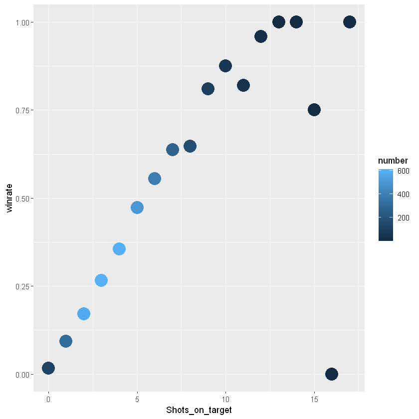

```r
g1 <- ggplot(Shots_on_target, aes(x=Shots_on_target, y=winrate))
g1 + geom_point(aes(colour=number), size=7)
```

#### 슈팅과 승률의 관계 : 슈팅수가 16개 이상이면 승률이 50% 이상이다.

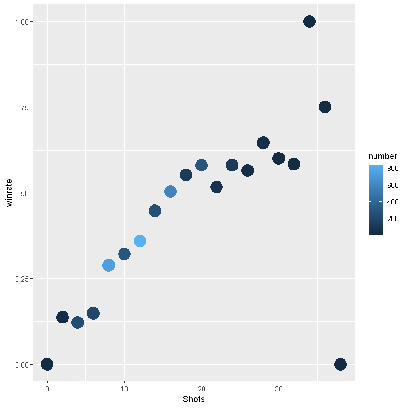

```r
g1 <- ggplot(Shots, aes(x=Shots, y=winrate))
g1 + geom_point(aes(colour=number), size=7)
```

#### 터치와 승률의 관계 : 터치수가 800회 이상이면 승률이 50% 이상이다.

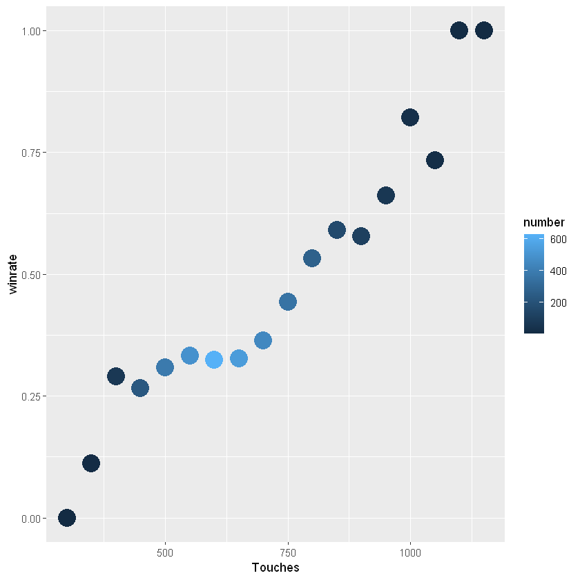

```r
g1 <- ggplot(Touches, aes(x=Touches, y=winrate))
g1 + geom_point(aes(colour=number), size=7)
```

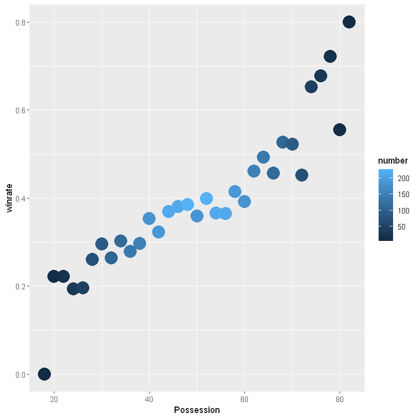

```r
g1 <- ggplot(Possession, aes(x=Possession, y=winrate))
g1 + geom_point(aes(colour=number), size=7)
```

#### 패스와 승률의 관계 : 패스수가 600회 이상이면 승률이 50% 이상이다.

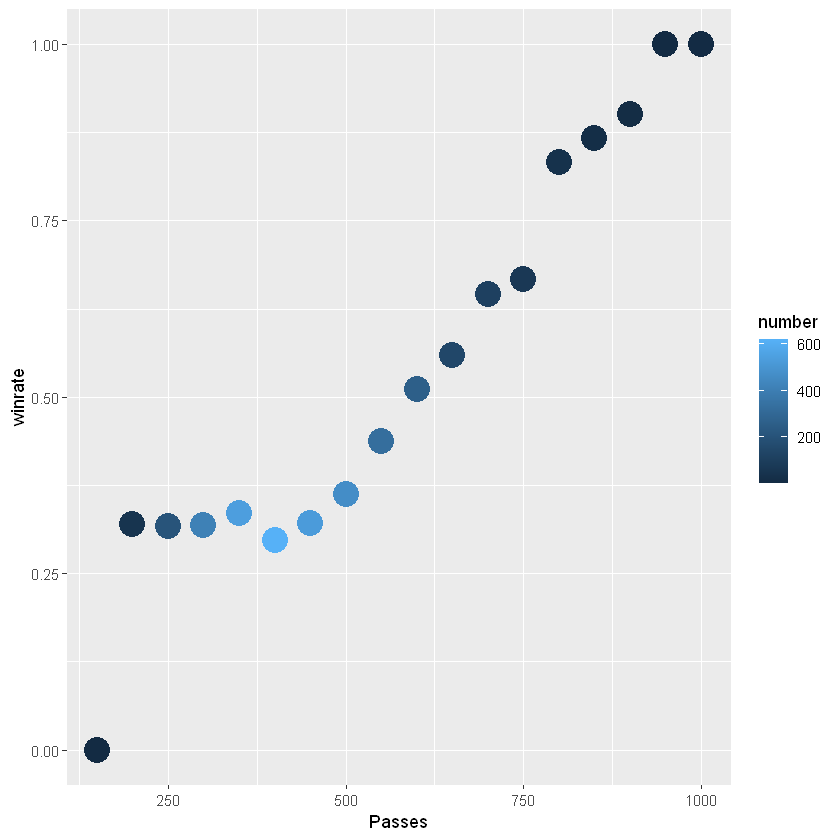

```r
g1 <- ggplot(Passes, aes(x=Passes, y=winrate))
g1 + geom_point(aes(colour=number), size=7)
```

#### 클리어링과 승률의 관계 : 클리어링 횟수가 54번이 넘어가면 승률이 50% 이상 이다.

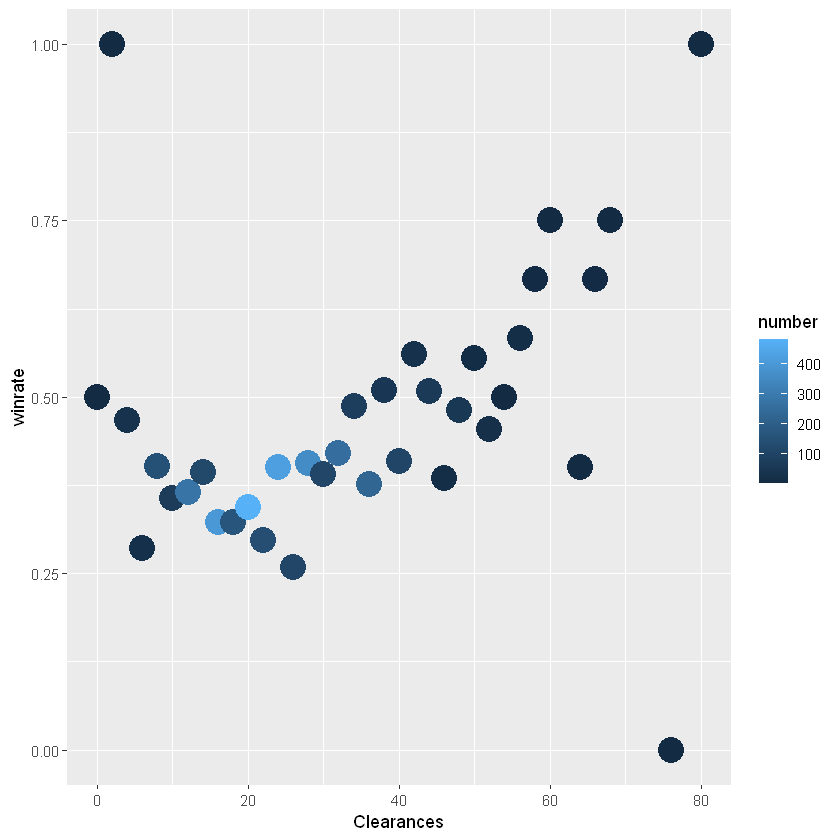

```r
g1 <- ggplot(Clearances, aes(x=Clearances, y=winrate))
g1 + geom_point(aes(colour=number), size=7)
```

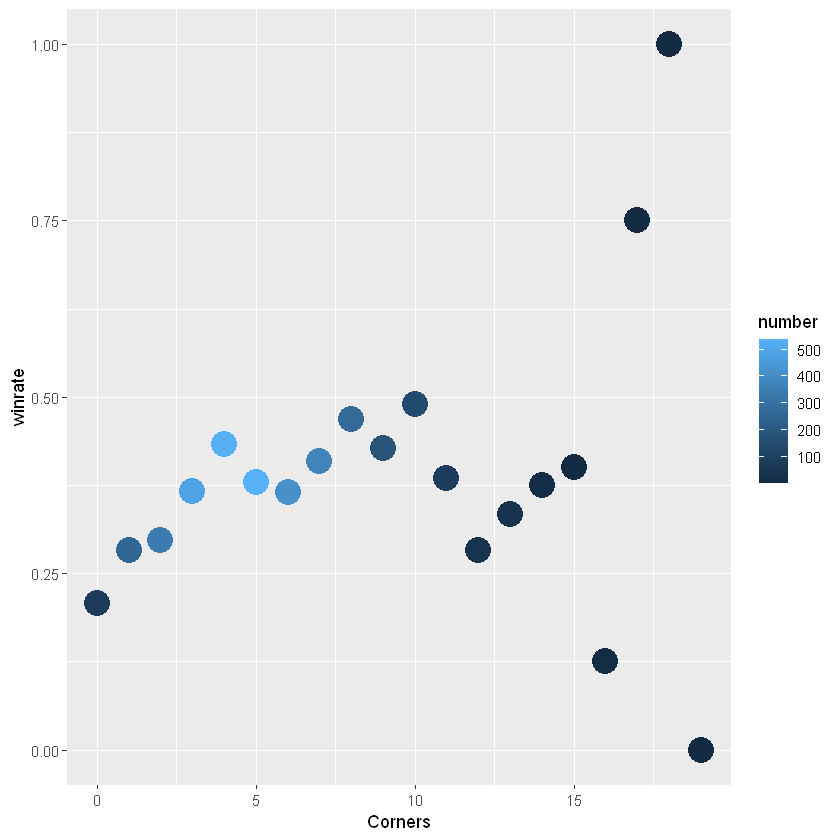

```r
g1 <- ggplot(Corners, aes(x=Corners, y=winrate))
g1 + geom_point(aes(colour=number), size=7)
```

### 음의 상관관계

#### 파울과 승률의 관계 : 파울을 3개 이하면 승률이 50% 이상 된다.

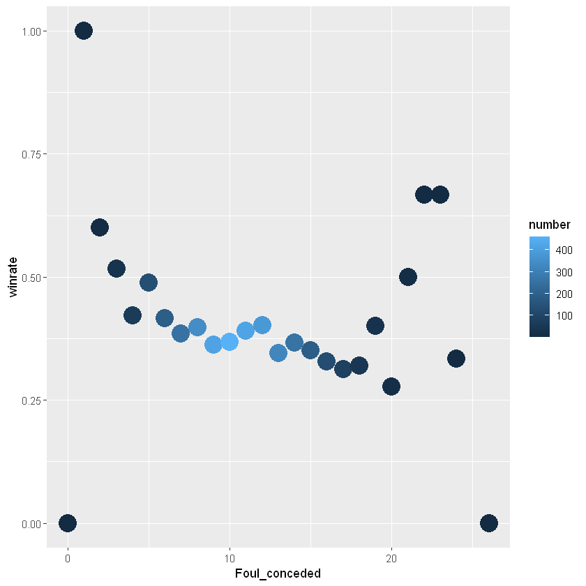

```r
g1 <- ggplot(Foul_conceded, aes(x=Foul_conceded, y=winrate))
g1 + geom_point(aes(colour=number), size=7)
```

#### 옐로카드와 승률의 관계 : 옐로카드가 적어야만 승률이 올라간다. 옐로카드가 없을때 승률이 거의 50% 근처로 간다.

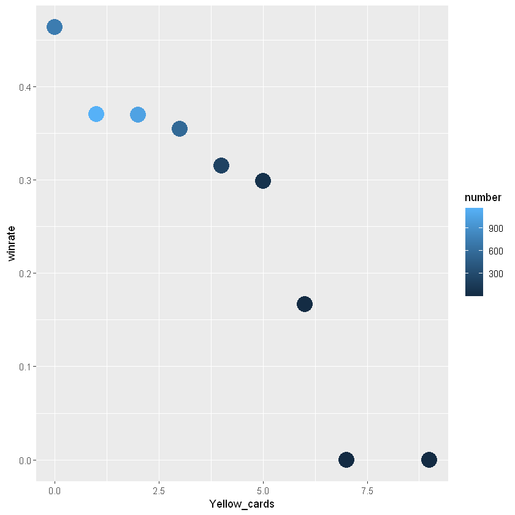

```r
g1 <- ggplot(Yellow_cards, aes(x=Yellow_cards, y=winrate))
g1 + geom_point(aes(colour=number), size=7)
```

#### 레드카드와 승률의 관계 : 한 경기에 받는 레드카드의 수치 범위가 너무 작으며 심지어 대부분 0에 해당하기 때문에 50% 이상의 승률이 되는 수치가 나타나지 않는다.

```r
Red_cards
```

| Red_cards | number | winrate |
| --- | --- | --- |
| 0 | 3573 | 0.3904282 |
| 1 | 220 | 0.2363636 |
| 2 | 7 | 0.0000000 |

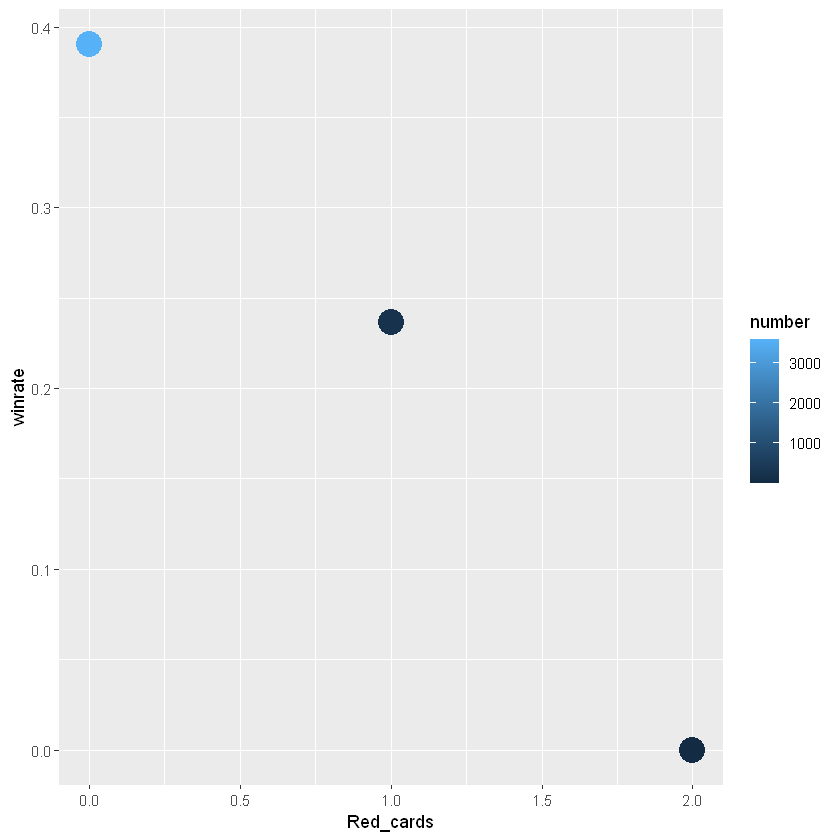

```r
g1 <- ggplot(Red_cards, aes(x=Red_cards, y=winrate))
g1 + geom_point(aes(colour=number), size=7)
```